# State MSM Profile: **Georgia**

### Background & Methods

In 2015-2016, researchers at Emory University partnered with colleagues at the Centers for Disease Control and Prevention (CDC) to develop methods to estimate the number of men who have sex with men (MSM) residing in each county in the United States. Using population and housing data from the [American Community Survey](https://www.census.gov/programs-surveys/acs/) and estimates from two peer-reviewed publications ([Oster et al., 2015](http://www.ncbi.nlm.nih.gov/pubmed/26115985) & [Purcell et al., 2012](http://www.ncbi.nlm.nih.gov/pubmed/23049658)), they derived an indirect estimate of MSM population sizes that took into account both the urbanicity of the county as well as its density of households with a male householder and a male same-sex partner.

The full methodology is published in the *Journal of Medical Internet Research - Public Health and Surveillance*:

> [Grey JA, Bernstein KT, Sullivan PS, Purcell DW, Chesson HW, Gift TL, Rosenberg ES. Estimating the population sizes of men who have sex with men in US states and counties using data from the American Community Survey. JMIR Public Health Surveill 2016;2(1):e14. DOI: 10.2196/publichealth.5365](http://publichealth.jmir.org/2016/1/e14/)

### Overview of MSM in Georgia

An estimated **131,373** men who have sex with men (MSM) resided in Georgia in 2013, representing 2.9% of the 4,503,084 MSM in the United States. Of the 3,522,525 adult men of Georgia, 3.7% had had sex with another man in the past 5 years, which was less than the overall percentage of adult men in the United States who were MSM (3.9%).

Most MSM in Georgia resided in fringe counties of large metropolitan areas (55.2%). Including both central and fringe counties, 78.1% resided in a large metropolitan area.

##### **Percentage of MSM by urbanicity, United States and Georgia, 2013**

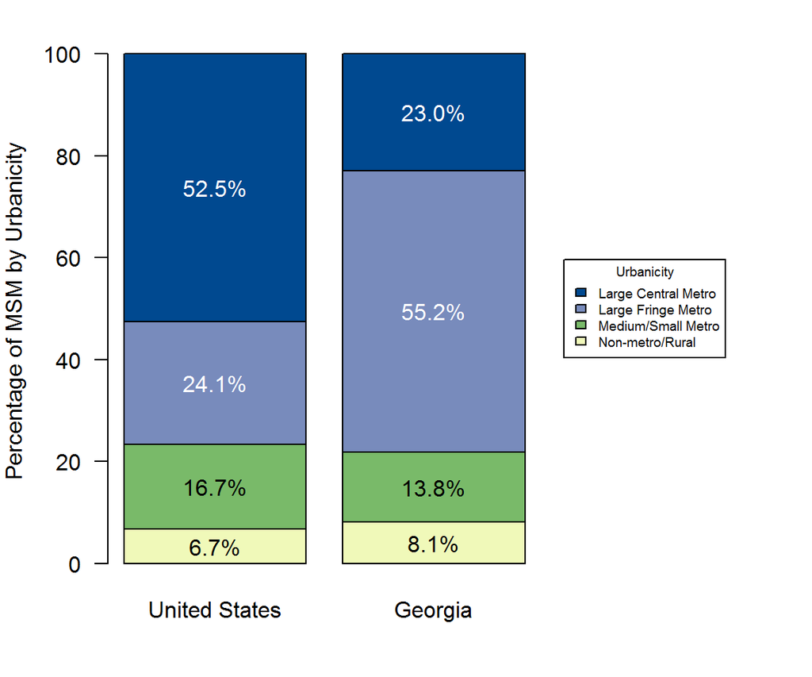

### MSM in Georgia Counties

Among counties or county-equivalent areas in Georgia, Fulton County had the largest population of MSM at 30,169, representing 23.0% of all MSM in the state. Fulton County also had the highest percentage of MSM among adult men in Georgia at 8.7%. This was greater than the percentage for Georgia as a whole, which was 3.7% of adult men.

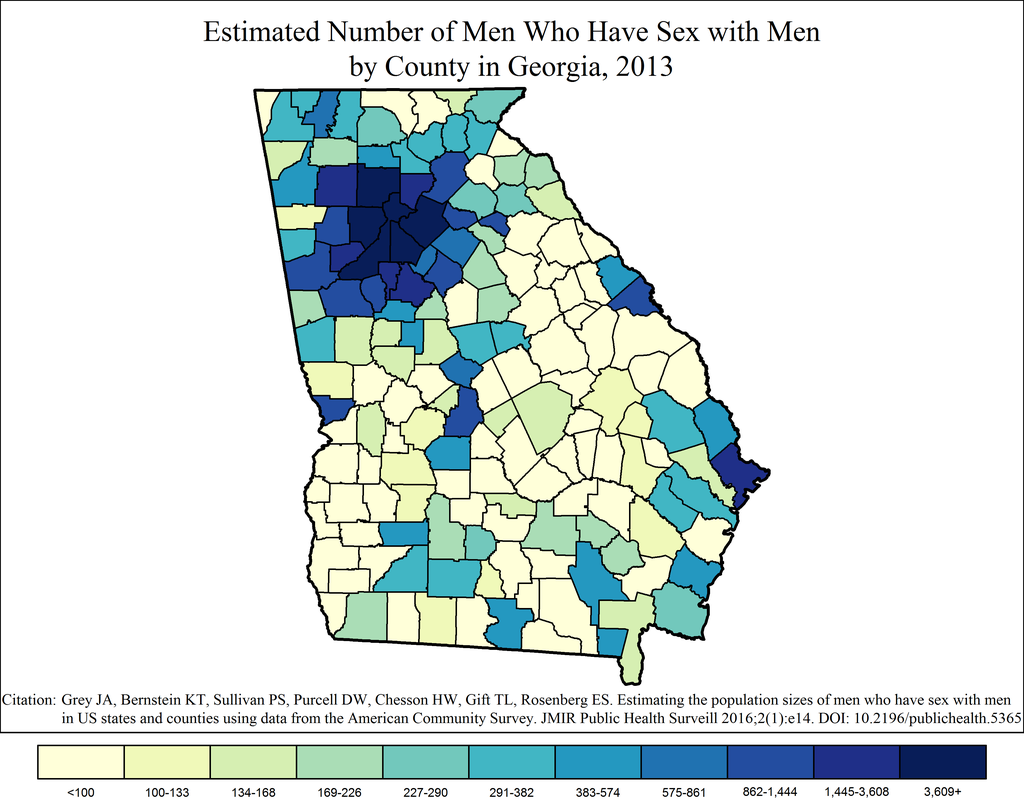

Note: Range cutpoints for the map are based on the distribution of MSM among all counties in the United States.

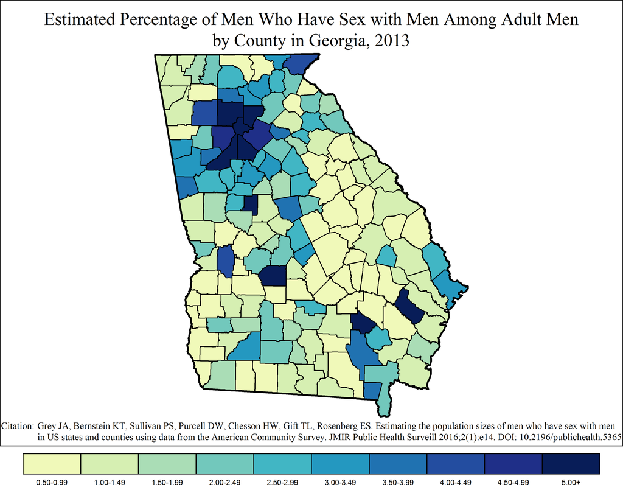

### MSM in Georgia Metropolitan Statistical Areas

#### Atlanta-Sandy Springs-Roswell Metropolitan Statistical Area

The Atlanta-Sandy Springs-Roswell MSA had the largest metropolitan population of MSM in Georgia at 102,642, or 78.1% of all MSM in the state. Of the 1,899,899 adult men in Atlanta-Sandy Springs-Roswell, an estimated 5.4% were MSM.

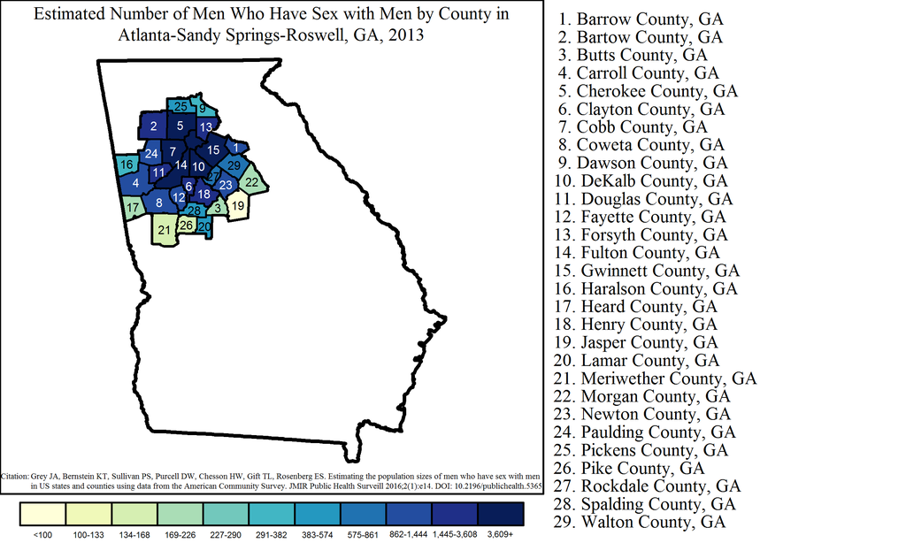

Note: Range cutpoints for the map are based on the distribution of MSM among all counties in the United States.

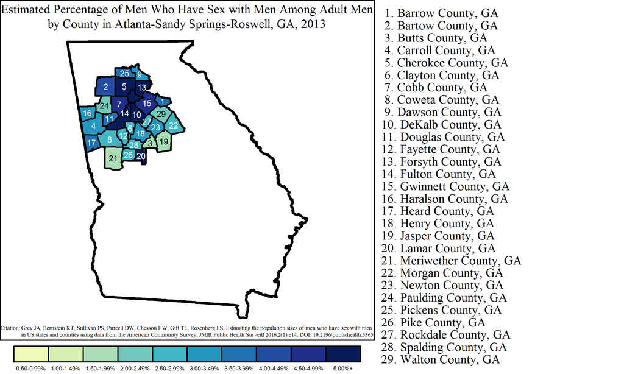

#### Savannah Metropolitan Statistical Area

The Savannah MSA had a population of 3,879 MSM, or 3.0% of all MSM in Georgia. Of the 129,232 adult men in Savannah, an estimated 3.0% were MSM.

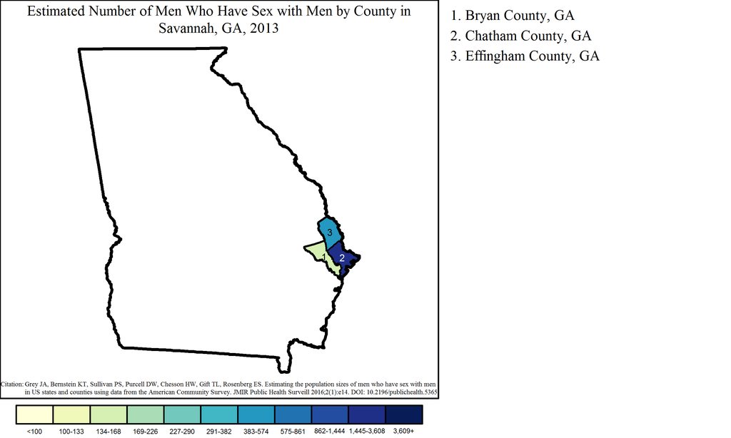

Note: Range cutpoints for the map are based on the distribution of MSM among all counties in the United States.

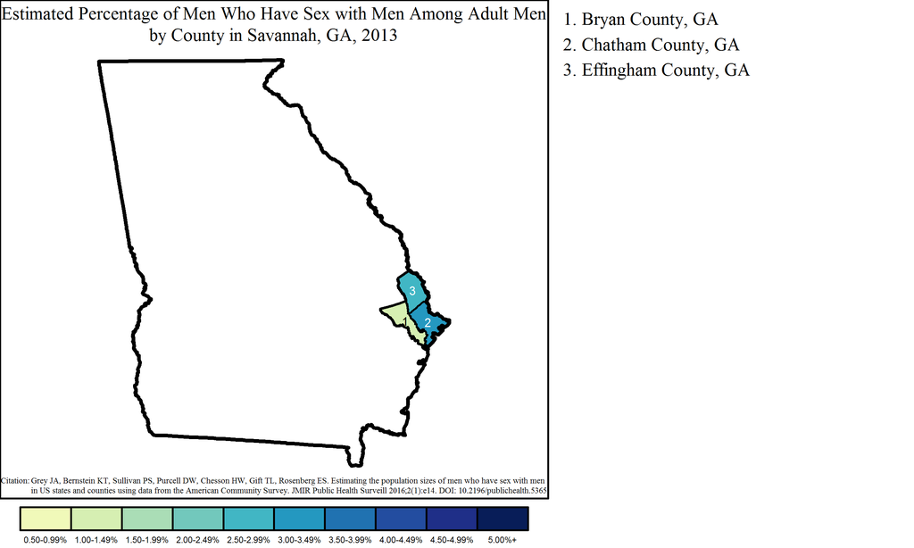

#### Athens-Clarke County Metropolitan Statistical Area

The Athens-Clarke County MSA had a population of 1,814 MSM, or 1.4% of all MSM in Georgia. Of the 73,431 adult men in Athens-Clarke County, an estimated 2.5% were MSM.

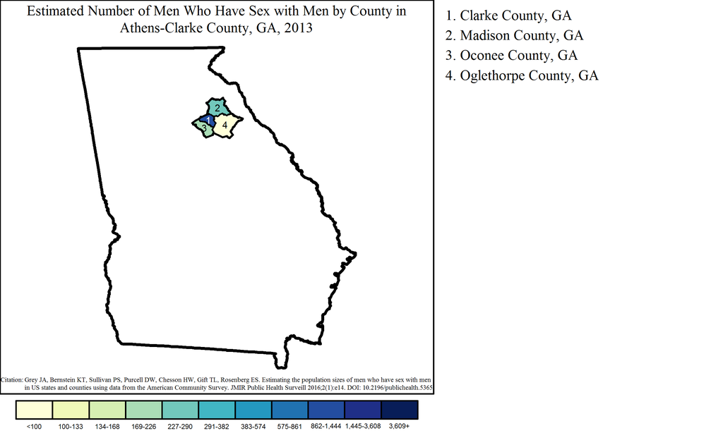

Note: Range cutpoints for the map are based on the distribution of MSM among all counties in the United States.

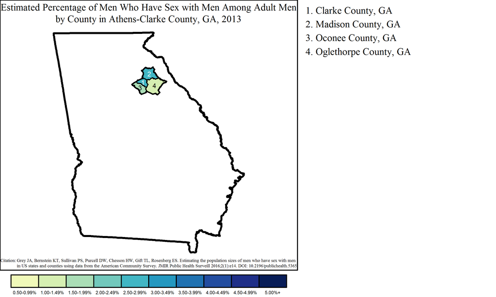

#### Columbus Metropolitan Statistical Area

The Columbus MSA overlaps two states: Alabama and Georgia. The Georgia portion of the MSA had 1,742 MSM, or 1.3% of all MSM in the state and 81.7% of the 2,132 MSM in the MSA. Of 91,019 adult men in the Georgia part of Columbus, 1.9% were MSM. This was equal to the overall percentage of MSM among adult men in the MSA, which was 1.9% of adult men (2,132 out of 110,539).

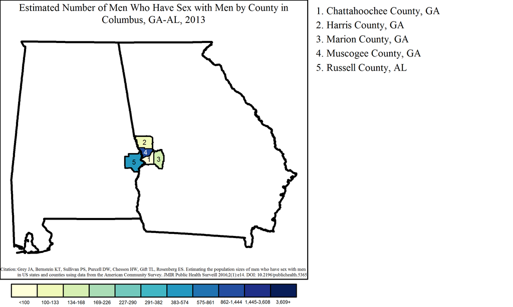

Note: Range cutpoints for the map are based on the distribution of MSM among all counties in the United States.

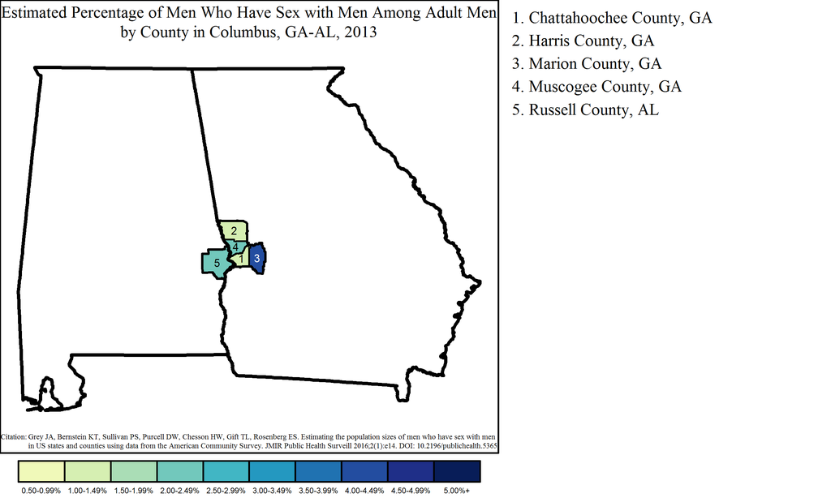

#### Augusta-Richmond County Metropolitan Statistical Area

The Augusta-Richmond County MSA overlaps two states: Georgia and South Carolina. The Georgia portion of the MSA had 1,673 MSM, or 1.3% of all MSM in the state and 52.4% of the 3,194 MSM in the MSA. Of 135,548 adult men in the Georgia part of Augusta-Richmond County, 1.2% were MSM. This was less than the overall percentage of MSM among adult men in the MSA, which was 1.5% of adult men (3,194 out of 206,844).

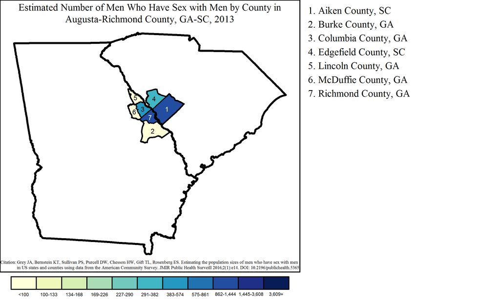

Note: Range cutpoints for the map are based on the distribution of MSM among all counties in the United States.

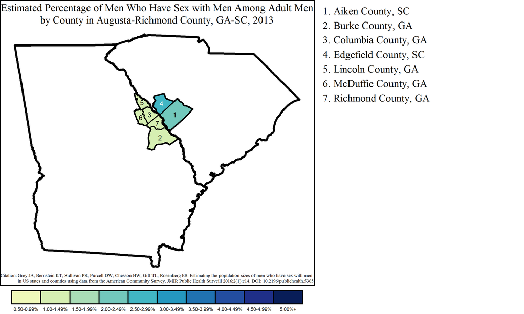

#### Gainesville Metropolitan Statistical Area

The Gainesville MSA had a population of 1,398 MSM, or 1.1% of all MSM in Georgia. Of the 65,404 adult men in Gainesville, an estimated 2.1% were MSM.

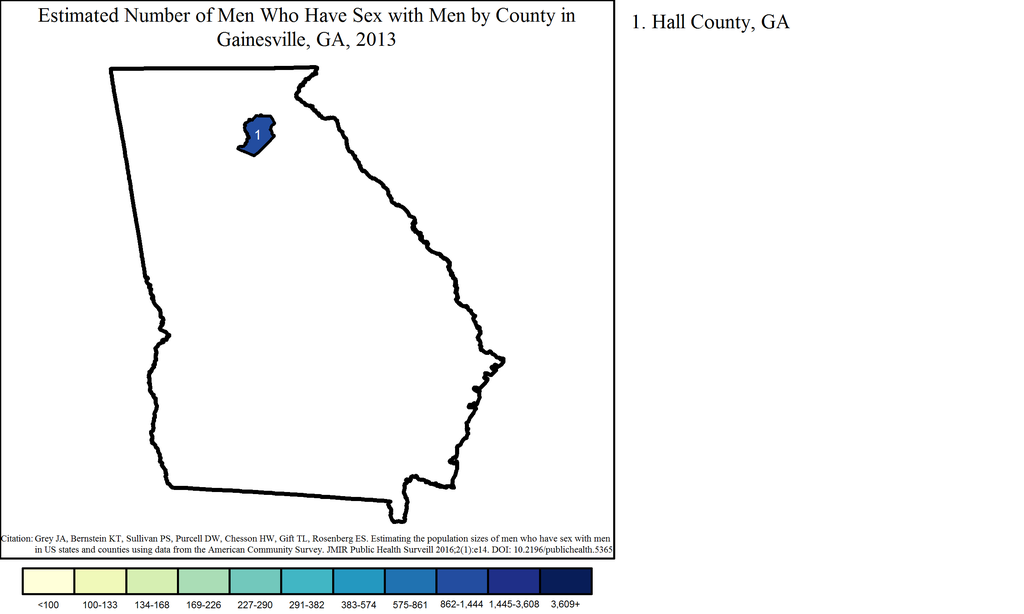

Note: Range cutpoints for the map are based on the distribution of MSM among all counties in the United States.

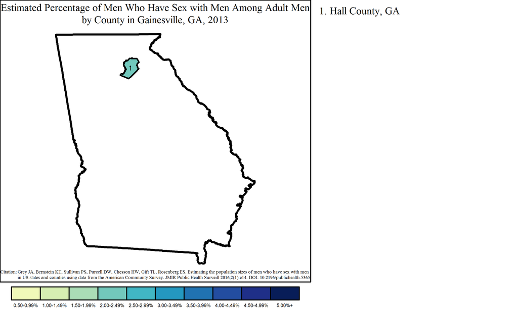

#### Macon Metropolitan Statistical Area

The Macon MSA had a population of 1,317 MSM, or 1.0% of all MSM in Georgia. Of the 81,541 adult men in Macon, an estimated 1.6% were MSM.

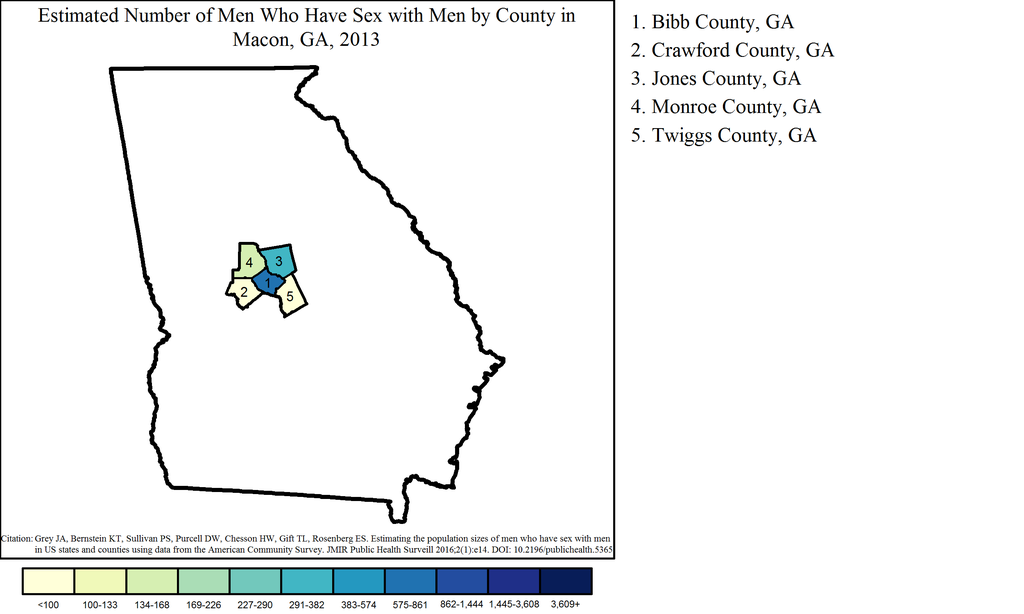

Note: Range cutpoints for the map are based on the distribution of MSM among all counties in the United States.

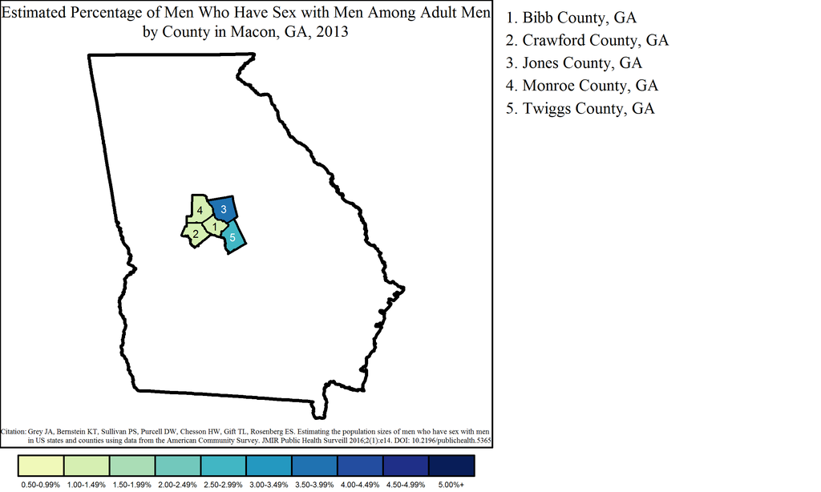

#### Warner Robins Metropolitan Statistical Area

The Warner Robins MSA had a population of 1,280 MSM, or 1.0% of all MSM in Georgia. Of the 64,407 adult men in Warner Robins, an estimated 2.0% were MSM.

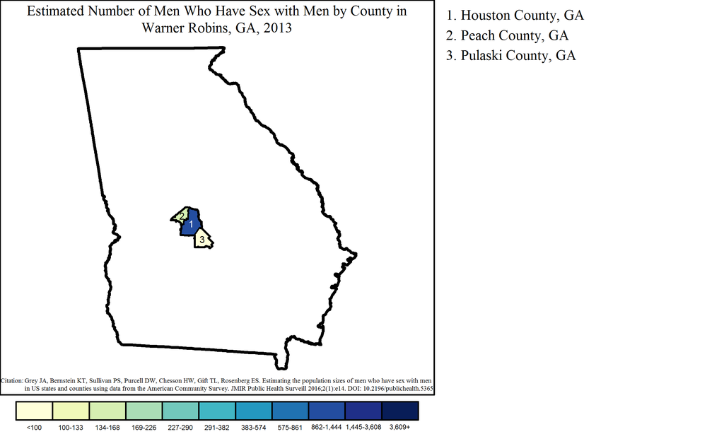

Note: Range cutpoints for the map are based on the distribution of MSM among all counties in the United States.

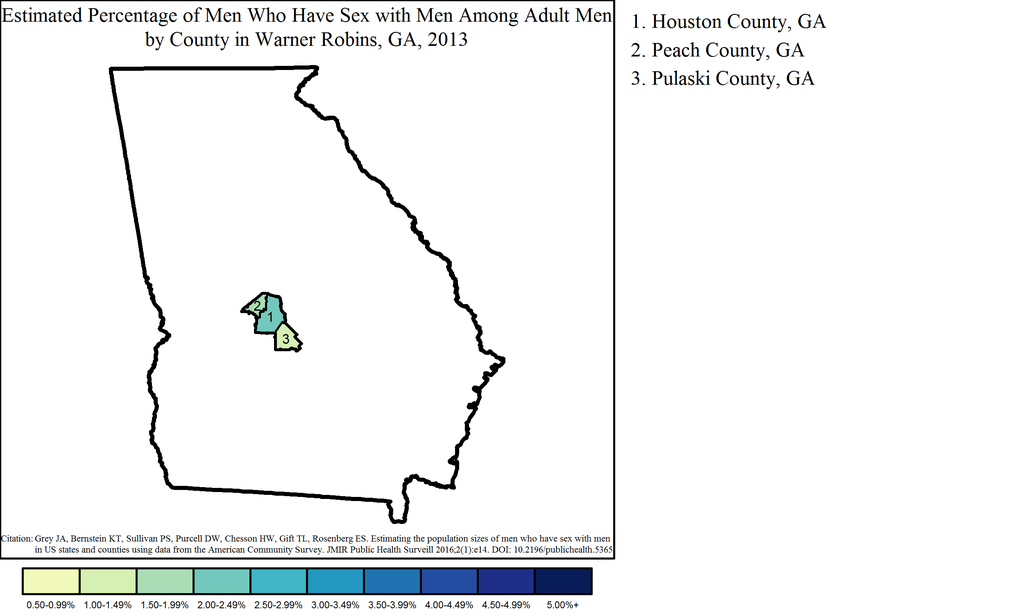

#### Dalton Metropolitan Statistical Area

The Dalton MSA had a population of 952 MSM, or 0.7% of all MSM in Georgia. Of the 50,743 adult men in Dalton, an estimated 1.9% were MSM.

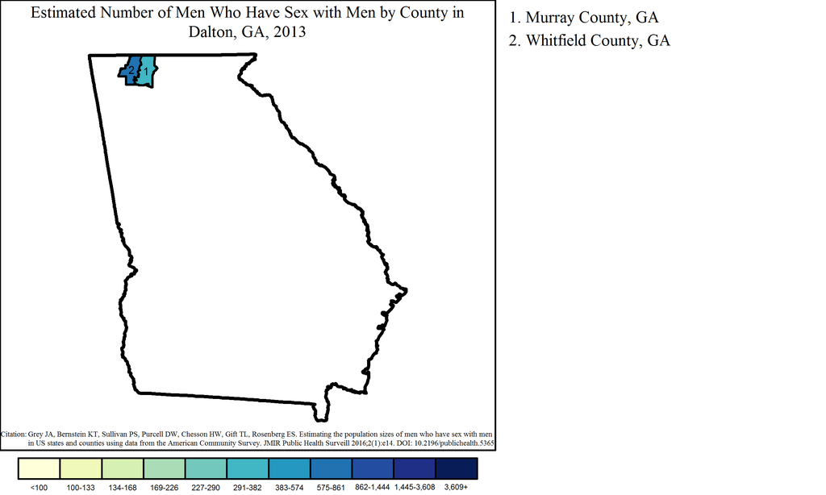

Note: Range cutpoints for the map are based on the distribution of MSM among all counties in the United States.

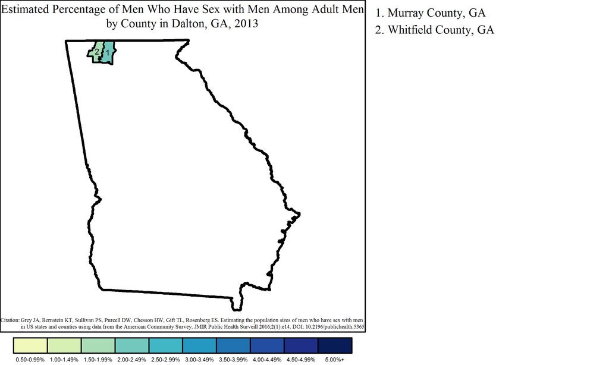

#### Albany Metropolitan Statistical Area

The Albany MSA had a population of 887 MSM, or 0.7% of all MSM in Georgia. Of the 54,264 adult men in Albany, an estimated 1.6% were MSM.

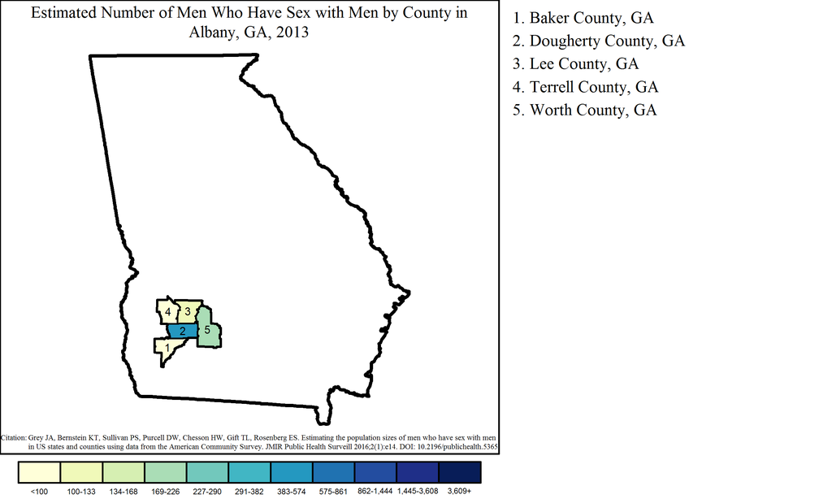

Note: Range cutpoints for the map are based on the distribution of MSM among all counties in the United States.

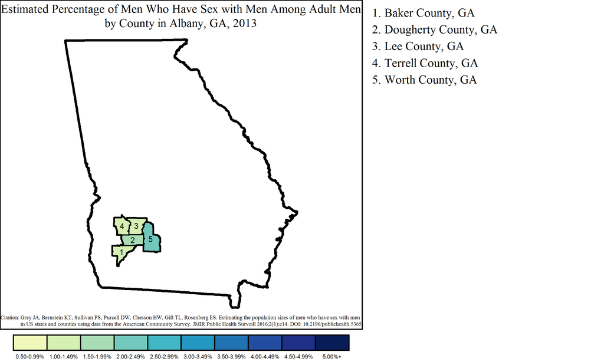

#### Chattanooga Metropolitan Statistical Area

The Chattanooga MSA overlaps two states: Georgia and Tennessee. The Georgia portion of the MSA had 742 MSM, or 0.6% of all MSM in the state and 18.1% of the 4,105 MSM in the MSA. Of 54,788 adult men in the Georgia part of Chattanooga, 1.4% were MSM. This was less than the overall percentage of MSM among adult men in the MSA, which was 2.1% of adult men (4,105 out of 197,662).

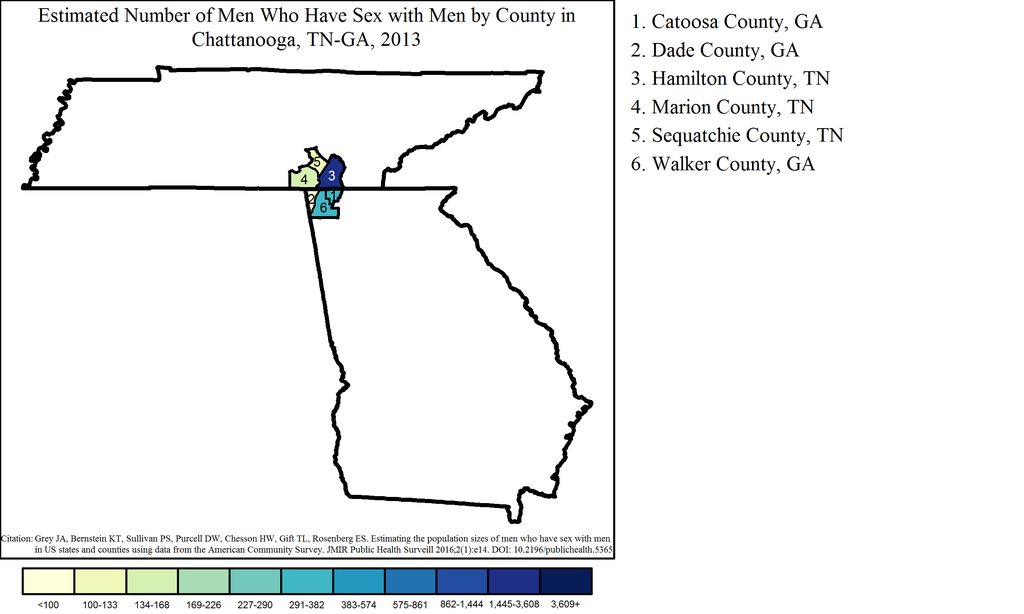

Note: Range cutpoints for the map are based on the distribution of MSM among all counties in the United States.

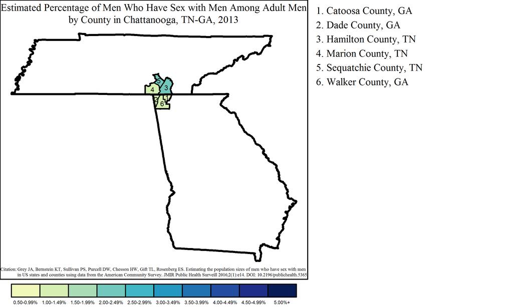

#### Hinesville Metropolitan Statistical Area

The Hinesville MSA had a population of 701 MSM, or 0.5% of all MSM in Georgia. Of the 27,974 adult men in Hinesville, an estimated 2.5% were MSM.

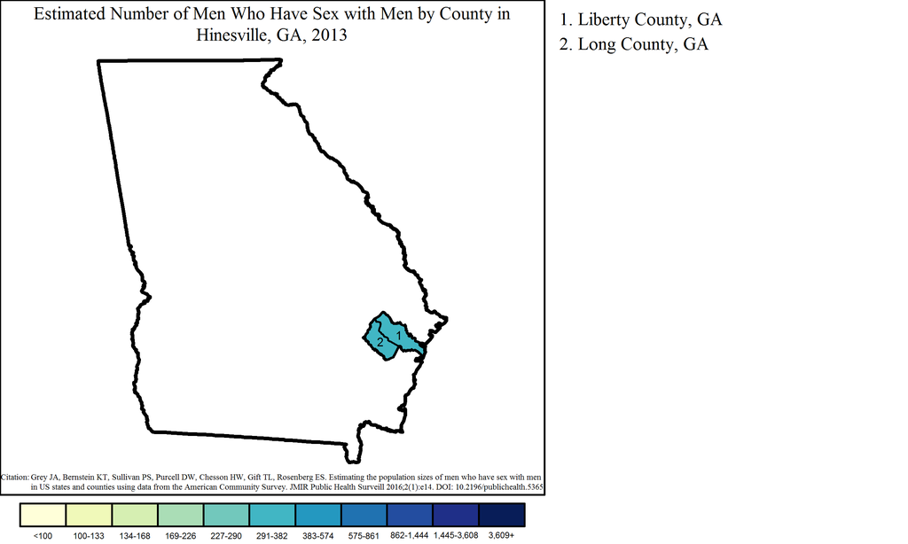

Note: Range cutpoints for the map are based on the distribution of MSM among all counties in the United States.

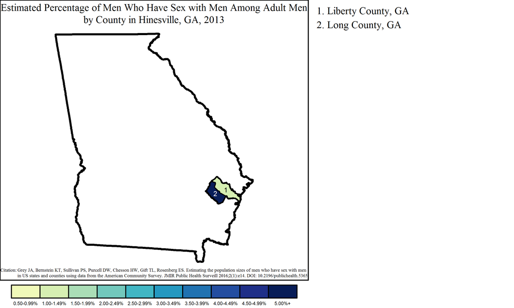

#### Valdosta Metropolitan Statistical Area

The Valdosta MSA had a population of 641 MSM, or 0.5% of all MSM in Georgia. Of the 51,656 adult men in Valdosta, an estimated 1.2% were MSM.

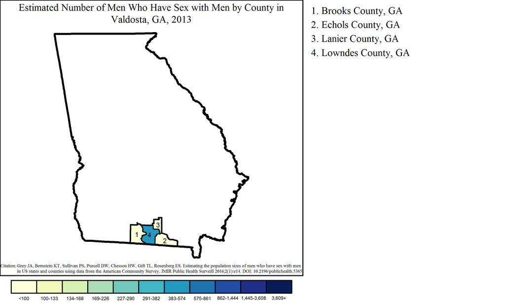

Note: Range cutpoints for the map are based on the distribution of MSM among all counties in the United States.

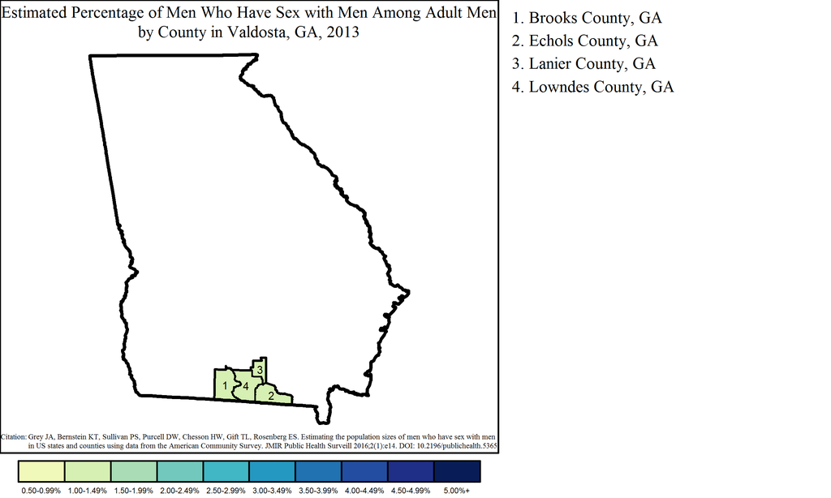

#### Brunswick Metropolitan Statistical Area

The Brunswick MSA had a population of 615 MSM, or 0.5% of all MSM in Georgia. Of the 40,634 adult men in Brunswick, an estimated 1.5% were MSM.

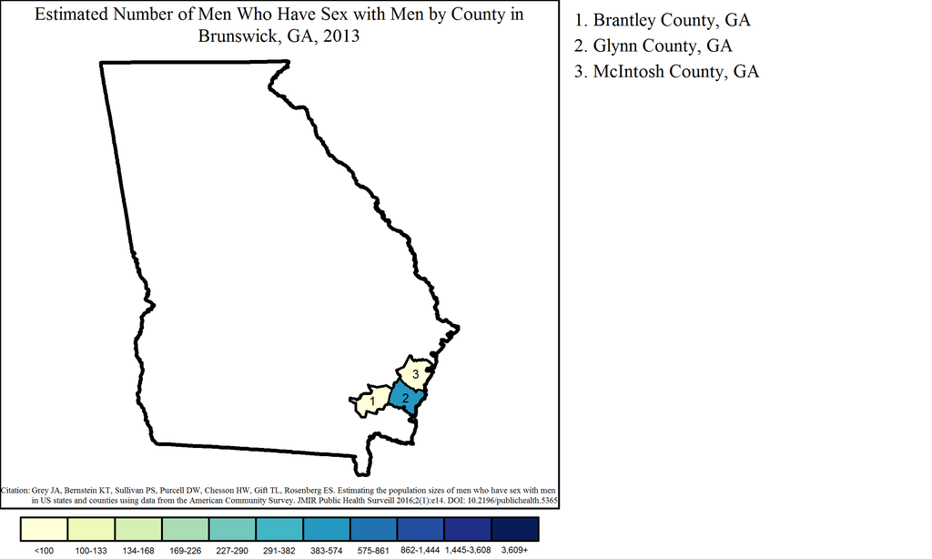

Note: Range cutpoints for the map are based on the distribution of MSM among all counties in the United States.

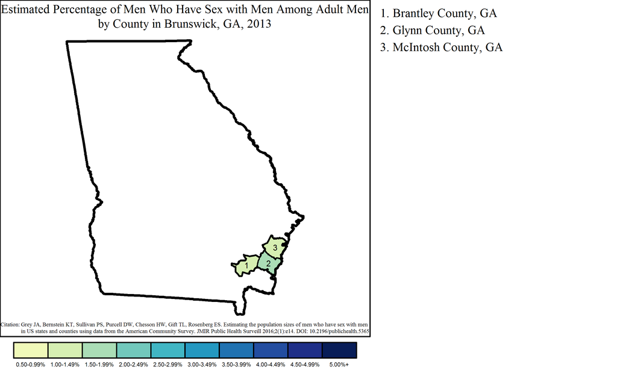